# Exercício 2 - Machine Learning - Regressão Linear

Amanda Provetti

2. Exercício 2 (Modelos de Regressão Linear Simples) Contexto do problema: Temos o objetivo de construir um modelo preditivo de ML que seja capaz de realizar predições dos valores medianos de preços das casas em uma região suburbana de Boston, EUA. A variável a ser predita consiste em um valor numérico que representa o preço mediano das casas em Boston. Para cada uma das observações (casas), temos diversas variáveis de entrada ou características. Logo, podemos buscar a solução para esse problema usando modelos de regressão linear simples ou múltipla. Dataset: Os dados estão fornecidos na forma de tabela (.xlsx e .csv) retratado pelo dataset Boston, presente na biblioteca MASS do software R que apresenta os valores das casas (Median value of owner-occupied homes) em 506 vizinhanças da cidade de Boston. Os dados que acompanham o valor mediano dos preços das casas consistem em indicadores de condições socioeconômicas, ambientais, instalações educacionais e alguns outros fatores semelhantes. No ambiente R, o comando ?Boston fornece informações sobre cada uma das features. Ao todo, são 13 features e uma variável resposta, denotada como medv (preço mediano da casa), baseada em $1,000 dólares. De forma específica, no conjunto de variáveis explanatórias (i.e., características), temos doze
12. variáveis numéricas e uma (1) variável categórica, que no caso pode assumir 0 (zero) ou 1 (um). Com isso, a planilha de dados apresenta 506 linhas (exemplos de treinamento) e 14 colunas (features). Abaixo, estão colocadas cada uma das variáveis características do dataset e seu respectivo significado:

• CRIM: per capita crime rate by town • ZN: proportion of residential land zoned for lots over 25,000 sq.ft. • INDUS: proportion of non-retail business acres per town • CHAS: Charles River dummy variable (= 1 if tract bounds river; 0 otherwise) • NOX: nitric oxides concentration (parts per 10 million) • RM: average number of rooms per dwelling • AGE: proportion of owner-occupied units built prior to 1940 • DIS: weighted distances to five Boston employment centres • RAD: index of accessibility to radial highways • TAX: full-value property-tax rate per 10,000 • PTRATIO: pupil-teacher ratio by town • B: 1000(Bk −0.63) 2 where Bk is the proportion of blacks by town • LSTAT: % lower status of the population • TARGET: Median value of owner-occupied homes in $1000’s

Em um primeiro momento, vamos usar a variável explanatória lstat, a qual expressa a parcela (em %) da população de baixa renda (status) obtida em cada vizinhança dentre as 506 analisadas. O nosso objetivo consiste em obter um modelo de ML baseado na regressão linear simples e univariada de lstat e os valores medianos dos preços das casas medv. Abaixo, seguem os itens que devemos solucionar neste desenvolvimento, visando alcançar o objetivo deste exercício:

– 1) Faça a exploração dos dados e a síntese sobre suas principais variáveis explanatórias.

```r
install.packages("ISLR")
library(ggplot2)
library(MASS)
library(ISLR)
library("tidyverse")
```

```r
data = Boston
data
```

|  | crim | zn | indus | chas | nox | rm | age | dis | rad | tax | ptratio | black | lstat | medv |
| --- | --- | --- | --- | --- | --- | --- | --- | --- | --- | --- | --- | --- | --- | --- |
| 1 | 0.00632 | 18.0 | 2.31 | 0 | 0.5380 | 6.575 | 65.2 | 4.0900 | 1 | 296 | 15.3 | 396.90 | 4.98 | 24.0 |
| 2 | 0.02731 | 0.0 | 7.07 | 0 | 0.4690 | 6.421 | 78.9 | 4.9671 | 2 | 242 | 17.8 | 396.90 | 9.14 | 21.6 |
| 3 | 0.02729 | 0.0 | 7.07 | 0 | 0.4690 | 7.185 | 61.1 | 4.9671 | 2 | 242 | 17.8 | 392.83 | 4.03 | 34.7 |
| 4 | 0.03237 | 0.0 | 2.18 | 0 | 0.4580 | 6.998 | 45.8 | 6.0622 | 3 | 222 | 18.7 | 394.63 | 2.94 | 33.4 |
| 5 | 0.06905 | 0.0 | 2.18 | 0 | 0.4580 | 7.147 | 54.2 | 6.0622 | 3 | 222 | 18.7 | 396.90 | 5.33 | 36.2 |
| 6 | 0.02985 | 0.0 | 2.18 | 0 | 0.4580 | 6.430 | 58.7 | 6.0622 | 3 | 222 | 18.7 | 394.12 | 5.21 | 28.7 |
| 7 | 0.08829 | 12.5 | 7.87 | 0 | 0.5240 | 6.012 | 66.6 | 5.5605 | 5 | 311 | 15.2 | 395.60 | 12.43 | 22.9 |
| 8 | 0.14455 | 12.5 | 7.87 | 0 | 0.5240 | 6.172 | 96.1 | 5.9505 | 5 | 311 | 15.2 | 396.90 | 19.15 | 27.1 |
| 9 | 0.21124 | 12.5 | 7.87 | 0 | 0.5240 | 5.631 | 100.0 | 6.0821 | 5 | 311 | 15.2 | 386.63 | 29.93 | 16.5 |
| 10 | 0.17004 | 12.5 | 7.87 | 0 | 0.5240 | 6.004 | 85.9 | 6.5921 | 5 | 311 | 15.2 | 386.71 | 17.10 | 18.9 |

[output cut: 496 more lines]

```r
summary(data)
```

```
      crim                zn             indus            chas              nox               rm
 Min.   : 0.00632   Min.   :  0.00   Min.   : 0.46   Min.   :0.00000   Min.   :0.3850   Min.   :3.561
 1st Qu.: 0.08204   1st Qu.:  0.00   1st Qu.: 5.19   1st Qu.:0.00000   1st Qu.:0.4490   1st Qu.:5.886
 Median : 0.25651   Median :  0.00   Median : 9.69   Median :0.00000   Median :0.5380   Median :6.208
 Mean   : 3.61352   Mean   : 11.36   Mean   :11.14   Mean   :0.06917   Mean   :0.5547   Mean   :6.285
 3rd Qu.: 3.67708   3rd Qu.: 12.50   3rd Qu.:18.10   3rd Qu.:0.00000   3rd Qu.:0.6240   3rd Qu.:6.623
 Max.   :88.97620   Max.   :100.00   Max.   :27.74   Max.   :1.00000   Max.   :0.8710   Max.   :8.780
      age              dis              rad              tax           ptratio          black
 Min.   :  2.90   Min.   : 1.130   Min.   : 1.000   Min.   :187.0   Min.   :12.60   Min.   :  0.32
 1st Qu.: 45.02   1st Qu.: 2.100   1st Qu.: 4.000   1st Qu.:279.0   1st Qu.:17.40   1st Qu.:375.38
 Median : 77.50   Median : 3.207   Median : 5.000   Median :330.0   Median :19.05   Median :391.44
 Mean   : 68.57   Mean   : 3.795   Mean   : 9.549   Mean   :408.2   Mean   :18.46   Mean   :356.67
 3rd Qu.: 94.08   3rd Qu.: 5.188   3rd Qu.:24.000   3rd Qu.:666.0   3rd Qu.:20.20   3rd Qu.:396.23
 Max.   :100.00   Max.   :12.127   Max.   :24.000   Max.   :711.0   Max.   :22.00   Max.   :396.90
     lstat            medv
 Min.   : 1.73   Min.   : 5.00
 1st Qu.: 6.95   1st Qu.:17.02
 Median :11.36   Median :21.20
 Mean   :12.65   Mean   :22.53
 3rd Qu.:16.95   3rd Qu.:25.00
 Max.   :37.97   Max.   :50.00
```

```r
names(data)
```

```
 [1] "crim"    "zn"      "indus"   "chas"    "nox"     "rm"      "age"     "dis"     "rad"     "tax"
[11] "ptratio" "black"   "lstat"   "medv"
```

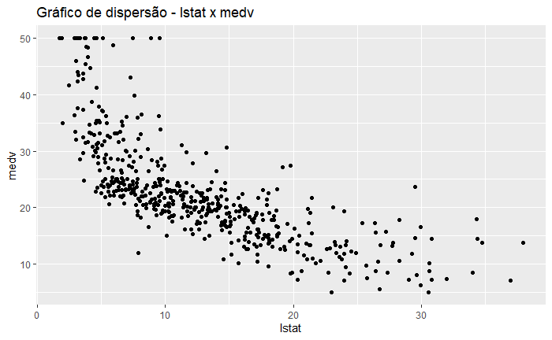

```r
data %>% ggplot(aes(x=lstat, y=medv)) +
  geom_point() +
  ggtitle("Gráfico de dispersão - lstat x medv") +
  xlab("lstat") +
  ylab("medv")
```

2. Construa e treine o modelo preditivo de ML baseado em regressão linear simples.

```r
modelo_ML <- lm(medv ~ lstat, data = data)
modelo_ML
```

```
Call:
lm(formula = medv ~ lstat, data = data)

Coefficients:
(Intercept)        lstat
      34.55        -0.95
```

3. Realize as predições do modelo sobre os dado de treinamento e calcule a média de seus resíduos.

```r
previsao_treinamento = predict(modelo_ML)
previsao_treinamento <- data.frame(previsao_treinamento)
previsao_treinamento
```

|  | previsao_treinamento |
| --- | --- |
| 1 | 29.8225951 |
| 2 | 25.8703898 |
| 3 | 30.7251420 |
| 4 | 31.7606958 |
| 5 | 29.4900778 |
| 6 | 29.6040837 |
| 7 | 22.7447274 |
| 8 | 16.3603958 |
| 9 | 6.1188637 |
| 10 | 18.3079969 |

[output cut: 496 more lines]

```r
media_residuos = mean(modelo_ML$residuals)
media_residuos
```

```
[1] 6.600194e-16
```

4. A partir do modelo de ML construído, qual seria o valor do preço de uma casa na região suburbana analisada de Boston, considerando que 25% das pessoas nesta localidade são classificadas na categoria de baixa renda?

```r
novo_dado      = data.frame(c(10, 15, 20, 25, 30, 35))
colnames(novo_dado) <- c('lstat')

predicao_teste <- predict(modelo_ML, novo_dado)
predicao_teste <- data.frame(predicao_teste*1000)
names(predicao_teste) <- c('Predição (dólares)')

predicao_teste
```

|  | Predição (dólares) |
| --- | --- |
| 1 | 25053.347 |
| 2 | 20303.101 |
| 3 | 15552.854 |
| 4 | 10802.607 |
| 5 | 6052.360 |
| 6 | 1302.113 |

5. Implemente o algoritmo do gradiente descendente.

```r
x = data$lstat
y = data$medv
num_iters     = 50000;
learning_rate = 0.001;

Algoritmo_GD <- function(X, y, theta, learning_rate, num_iters){
  m = length(y)
  theta  = c(0, 0)
  alpha = learning_rate
  for (i in 1:num_iters){
    h      = theta[1] + theta[2]*x
    Theta0 = theta[1]
    Theta1 = theta[2]
    Theta0 = Theta0 - alpha*(1/m)*sum((h - y))
    Theta1 = Theta1 - alpha*(1/m)*sum((h - y)*x)
    theta  = c(Theta0, Theta1)
  }
  theta
}
theta_GD <- Algoritmo_GD(x, y, theta, learning_rate, num_iters)
theta_GD
```

```
[1] 34.5536329 -0.9500369
```

6. Solucione o problema com as equações normais e faça um comparativo de resultados

```r
size_data = dim(data)
ones_data = replicate(size_data[1],1)

X = data.frame(ones_data,x)
X = as.matrix(X)

theta_solution_norm_equations = solve(t(X) %*% X) %*% (t(X) %*% y)
theta_0_norm_eq = theta_solution_norm_equations[1]
theta_1_norm_eq = theta_solution_norm_equations[2]
theta_0_norm_eq
```

```
[1] 34.55384
```

```r
theta_1_norm_eq
```

```
[1] -0.9500494
```

7. Compare os resultados do modelo construído com os parâmetros obtidos com o algoritmo GD

```r
summary(modelo_ML)
```

```
Call:
lm(formula = medv ~ lstat, data = data)

Residuals:
    Min      1Q  Median      3Q     Max
-15.168  -3.990  -1.318   2.034  24.500

Coefficients:
            Estimate Std. Error t value Pr(>|t|)
(Intercept) 34.55384    0.56263   61.41   <2e-16 ***
lstat       -0.95005    0.03873  -24.53   <2e-16 ***
---
Signif. codes:  0 ‘***’ 0.001 ‘**’ 0.01 ‘*’ 0.05 ‘.’ 0.1 ‘ ’ 1

Residual standard error: 6.216 on 504 degrees of freedom
Multiple R-squared:  0.5441,    Adjusted R-squared:  0.5432
F-statistic: 601.6 on 1 and 504 DF,  p-value: < 2.2e-16
```

```r
theta_GD
```

```
[1] 34.5536329 -0.9500369
```